# Regresja i analiza wariancji - Sprawozdanie 2

Analiza wariancji

Lidia Furgał, Karolina Majdak

Politechnika Krakowska

# Analiza Wpływu Zmiany Szaty Graficznej Strony na Sprzedaż Smartfona

Zarząd firmy ,,Firma na A”, zajmującej się m.in. sprzedażą telefonów komórkowych, rozważa zmianę szaty graficznej strony internetowej, na której klienci mogą zakupić ich flagowy smartfon. Aby zbadać wpływ nowych projektów strony na liczbę sprzedanych urządzeń, przeprowadzono eksperyment metodą testu A/B/C, w którym badano efektywność dwóch nowych wersji strony w porównaniu do obecnie używanej.

**Wersja 1**: Obecna szata graficzna (kontrolna).

**Wersja 2**: Nowa wersja z dużym prostokątnym czerwonym przyciskiem ,,Kup Teraz”.

**Wersja 3**: Nowa wersja z dużym okrągłym srebrnym przyciskiem ,,Kup Teraz”.

Dla każdej wersji strony mierzono liczbę sprzedanych smartfonów w danym okresie. Dane zawierają następujące zmienne:

- **version** – wersja strony (1 - obecna wersja, 2 - wersja z prostokątnym przyciskiem, 3 - wersja z okrągłym przyciskiem),
- **sales** – liczba sprzedanych sztuk smartfona.

Celem analizy jest odpowiedź na dwa kluczowe pytania:

- Czy zmiana wyglądu strony wpływa na liczbę sprzedanych smartfonów? Jeśli tak, to która z nowych wersji strony jest najskuteczniejsza?

Aby ocenić, czy wprowadzenie nowych szat graficznych strony internetowej wpłynęło na liczbę sprzedanych smartfonów, najpierw dokonamy wstępnej eksploracji danych dostarczonych przez zarząd firmy ,,Firma na A”. W ramach tego kroku wyświetlimy kilka pierwszych wierszy zebranych danych, aby lepiej zrozumieć ich strukturę oraz zmienne, które będą poddane dalszej analizie.

```r
sites <- readr::read_csv('zadanie1.csv')
head(sites)
```

| version | sales |
| --- | --- |
| 1 | 295 |
| 1 | 115 |
| 1 | 201 |
| 1 | 251 |
| 1 | 237 |
| 1 | 320 |

Zauważmy, że próby zostały pobrane losowo i niezależnie dla każdej z analizowanych grup, co wskazuje na odpowiednie zaprojektowanie badania oraz pozwala na wiarygodne wyciąganie wniosków.

Aby odpowiedzieć na pytanie, czy zmiana szaty graficznej strony wpłynęła na liczbę sprzedanych smartfonów, zastosujemy jednoczynnikową analizę wariancji (**ANOVA**). W tym przypadku zmienną objaśnianą (zależną) będzie liczba sprzedanych smartfonów (*sales*), natomiast zmienną objaśniającą (niezależną) będzie wersja strony internetowej (*version*).

```r
sites <- sites %>% dplyr::mutate(version = as.character(version))
```

Aby ocenić, czy rozkład prób w każdej grupie (wersji strony) jest zbliżony do rozkładu normalnego, wykorzystamy wykres typu **boxplot**.

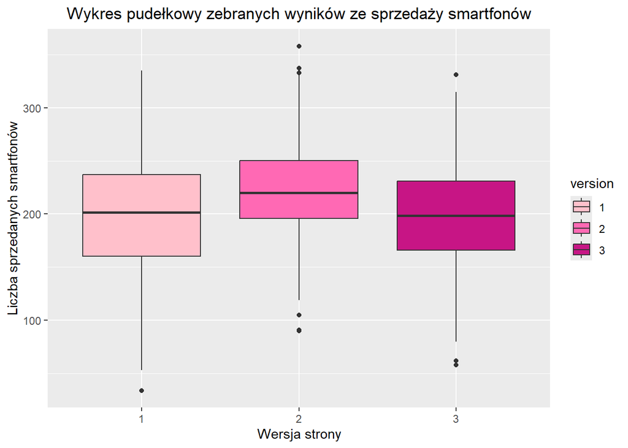

```r
ggplot(sites, aes(x=version, y=sales,fill=version)) + geom_boxplot() + scale_fill_manual(values=c("#FFC0CB", "#FF69B4", "#C71585"))+ labs(title = "Wykres pudełkowy zebranych wyników ze sprzedaży smartfonów", x='Wersja strony', y='Liczba sprzedanych smartfonów')+ theme(plot.title = element_text(hjust = 0.5))
```

Na podstawie powyższego wykresu **boxplot** możemy stwierdzić, że rozkłady dla każdej grupy wydają się zbliżone do rozkładu normalnego.

Aby sprawdzić, czy wariancja w poszczególnych grupach (wersjach strony) jest stała, wykonamy wykres punktowy. Taki wykres pozwoli na wizualną ocenę rozkładu punktów w każdej z grup i porównanie, czy rozproszenie wartości w poszczególnych grupach jest podobne.

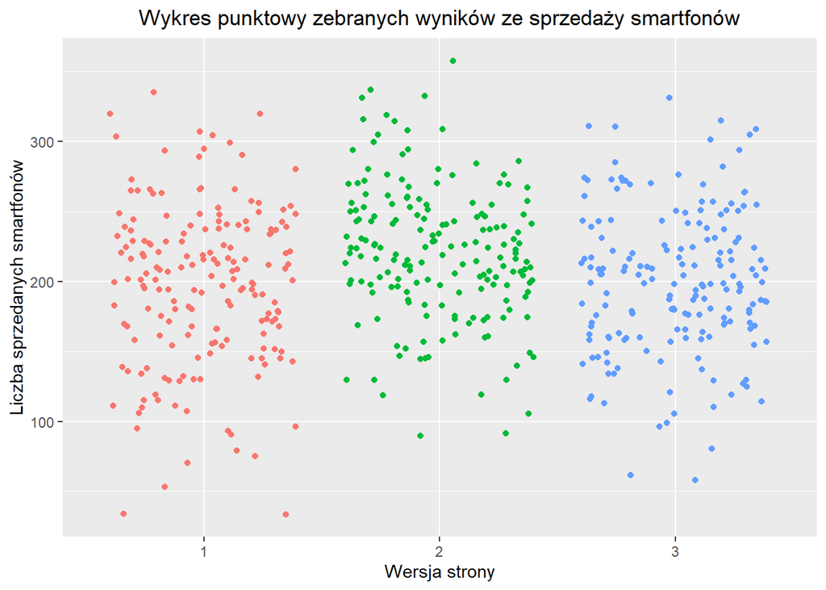

```r
ggplot(sites, aes(x=version, y=sales)) + geom_point(aes(color=version), position='jitter') + labs(title = "Wykres punktowy zebranych wyników ze sprzedaży smartfonów", x='Wersja strony', y='Liczba sprzedanych smartfonów') + theme(legend.position = 'none')+ theme(plot.title = element_text(hjust = 0.5))
```

Zauważmy, że na podstawie wykresu punktowego, obserwacje w każdej grupie są równomiernie rozproszone wokół swoich średnich. Oznacza to, że rozproszenie danych (czyli wariancja) w poszczególnych grupach jest zbliżone. Możemy zatem stwierdzić, że założenie o jednorodności wariancji zostało spełnione, co jest kluczowe dla prawidłowego przeprowadzenia analizy wariancji (**ANOVA**).

W związku z powyższym, przeprowadzimy jednoczynnikową analizę wariancji (**ANOVA**). Przypomnijmy, że hipotezy są sformułowane w następujący sposób:
$$H_0:
\mu_1 = \mu_2 = \dots = \mu_k, \\
H_1: \text{przynajmniej jedna ze srednich} \; \mu_i \; \text{jest rozna
od pozostalych.}$$

```r
summary(aov(sales ~ version, data=sites))
```

```
##              Df  Sum Sq Mean Sq F value   Pr(>F)
## version       2   60968   30484   11.13 1.83e-05 ***
## Residuals   537 1470699    2739
## ---
## Signif. codes:  0 '***' 0.001 '**' 0.01 '*' 0.05 '.' 0.1 ' ' 1
```

Na podstawie uzyskanej wartości **p-value** ($p < 0,001$), która jest mniejsza od przyjętego poziomu istotności, możemy odrzucić hipotezę zerową. W związku z tym stwierdzamy, że wersja strony internetowej ma istotny wpływ na liczbę sprzedanych smartfonów.

Z uwagi na to, że wynik analizy wariancji wskazuje jedynie na istnienie różnicy w liczbie sprzedanych smartfonów między trzema wersjami strony internetowej, przeprowadzimy procedurę Tukeya-Kramera. Dzięki tej analizie będziemy mogli zidentyfikować konkretne wersje strony, które różnią się pod względem liczby sprzedanych smartfonów.

```r
TukeyHSD(aov(sales ~ version, data=sites))
```

```
##   Tukey multiple comparisons of means
##     95% family-wise confidence level
##
## Fit: aov(formula = sales ~ version, data = sites)
##
## $version
##           diff       lwr       upr     p adj
## 2-1  23.672222  10.70749 36.636953 0.0000625
## 3-1   2.466667 -10.49806 15.431398 0.8956845
## 3-2 -21.205556 -34.17029 -8.240825 0.0003977
```

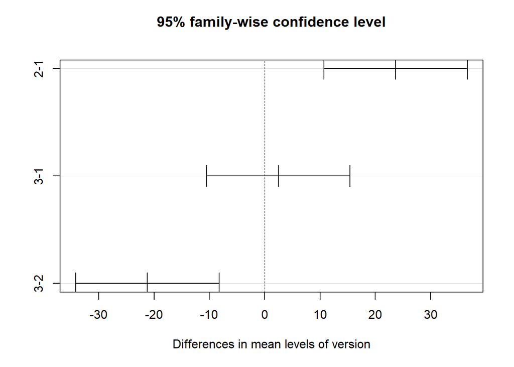

```r
plot(TukeyHSD(aov(sales ~ version, data=sites)))
```

Na podstawie przedstawionego wykresu możemy stwierdzić, że średnia różnica w liczbie sprzedanych smartfonów jest wyraźnie większa dla strony internetowej z prostokątnym, czerwonym guzikiem „kup teraz” w porównaniu do starej wersji. Ponadto zauważamy, że średnia różnica w liczbie sprzedanych smartfonów jest niższa dla strony z dużym, okrągłym, srebrnym guzikiem „kup teraz” w odniesieniu do nowej wersji strony z prostokątnym przyciskiem.

# Analiza Wpływu Nowej Funkcjonalności Autoodtwarzania na Czas Oglądania Wideo

Po sukcesie w zakresie wyboru szaty graficznej strony, zarząd ,,Firmy na A” zlecił zespołowi nowy projekt, mający na celu ocenę efektywności nowej funkcjonalności autoodtwarzania w zakresie streamingu wideo. Inżynierowie firmy są przekonani, że nowa funkcjonalność wydłuży czas oglądania wideo przez użytkowników, co przełoży się na wzrost przychodów z reklam. Szczególne nadzieje wiązane są z tym, że zmiana ta będzie miała największy wpływ na młodszych odbiorców.

W ramach projektu przeprowadzono test A/B, w którym użytkownicy zostali losowo przypisani do jednej z dwóch wersji strony:

**Wersja 1**: Stary odtwarzacz

**Wersja 2**: Nowy odtwarzacz

Aby ocenić skuteczność nowej funkcjonalności, zastosowano dwuczynnikową analizę wariancji (**ANOVA**).

Zebrane dane obejmują trzy grupy użytkowników oraz dwie wersje odtwarzacza:

Grupa (**group**):

- Użytkownicy poniżej 16 roku życia
- Użytkownicy w wieku od 16 do 39 lat
- Użytkownicy powyżej 40 roku życia

Wersja (**version**):

- Wersja ze starym odtwarzaczem
- Wersja z nowym odtwarzaczem
- Czas (**time**): Czas spędzony na oglądaniu w danej sesji, mierzony w minutach.

```r
player <- readr::read_csv('zadanie2.csv')
head(player)
```

| group | time | version |
| --- | --- | --- |
| 1 | 65 | 1 |
| 1 | 60 | 2 |
| 1 | 53 | 1 |
| 1 | 65 | 1 |
| 1 | 64 | 1 |
| 1 | 65 | 1 |

Zauważmy, że próby zostały ponownie pobrane w sposób losowy i niezależnie dla każdej z analizowanych grup, co potwierdza staranność w zaprojektowaniu badania.

Aby zweryfikować hipotezę, czy nowa funkcjonalność autoodtwarzania zwiększa czas oglądania wideo, szczególnie wśród dzieci, przeprowadzimy dwuczynnikową analizę wariancji (**ANOVA**). Zmienną objaśnianą będzie czas oglądania, natomiast czynnikami analizy będą grupy użytkowników oraz wersje odtwarzacza.

W pierwszej kolejności odpowiednio przygotujemy dane do dalszej analizy, a następnie dokonamy weryfikacji założeń analizy wariancji.

```r
player <- player %>% dplyr::mutate(group = as.factor(group)) %>% dplyr::mutate(version = as.factor(version))
```

Na początku dokonamy oceny, czy rozkład prób w poszczególnych grupach jest zbliżony do rozkładu normalnego. W tym celu stworzymy wykres typu **boxplot**, który pozwoli na wizualizację rozkładów czasów oglądania wideo w każdej z analizowanych grup.

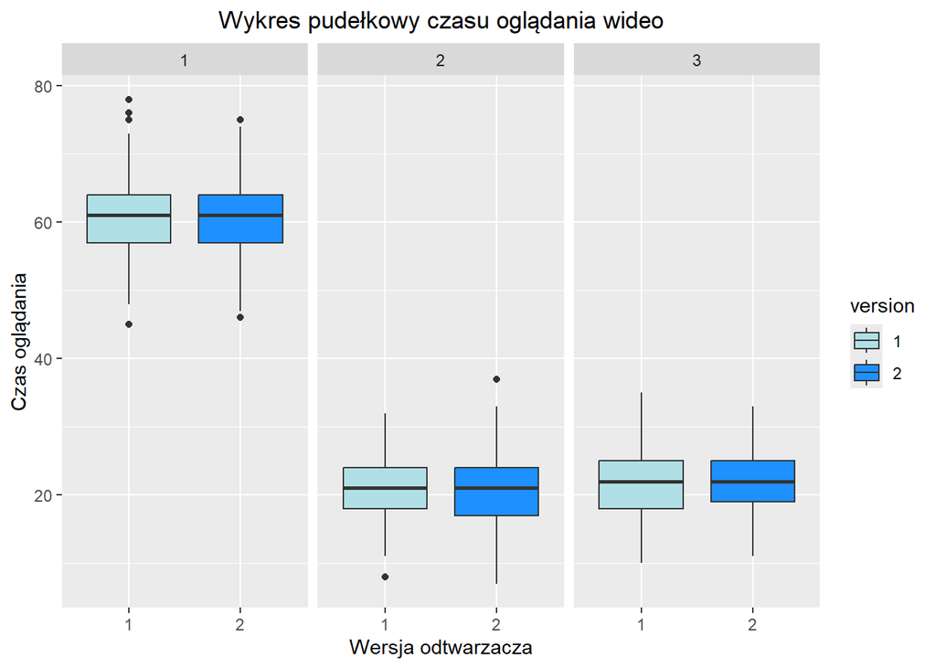

```r
ggplot(player, aes(x=version, y=time,fill=version)) + geom_boxplot() + scale_fill_manual(values=c("#B0E0E6", "#1E90FF")) + facet_wrap(~group)+labs(title = "Wykres pudełkowy czasu oglądania wideo", x='Wersja odtwarzacza', y='Czas oglądania')+ theme(plot.title = element_text(hjust = 0.5))
```

W związku z powyższym wykresem **boxplot** możemy stwierdzić, że rozkład prób w każdej grupie jest zbliżony do rozkładu normalnego.

Aby ocenić jednorodność wariancji, przeprowadzimy analizę z wykorzystaniem wykresu punktowego, który umożliwi wizualizację rozkładów wariancji w poszczególnych grupach.

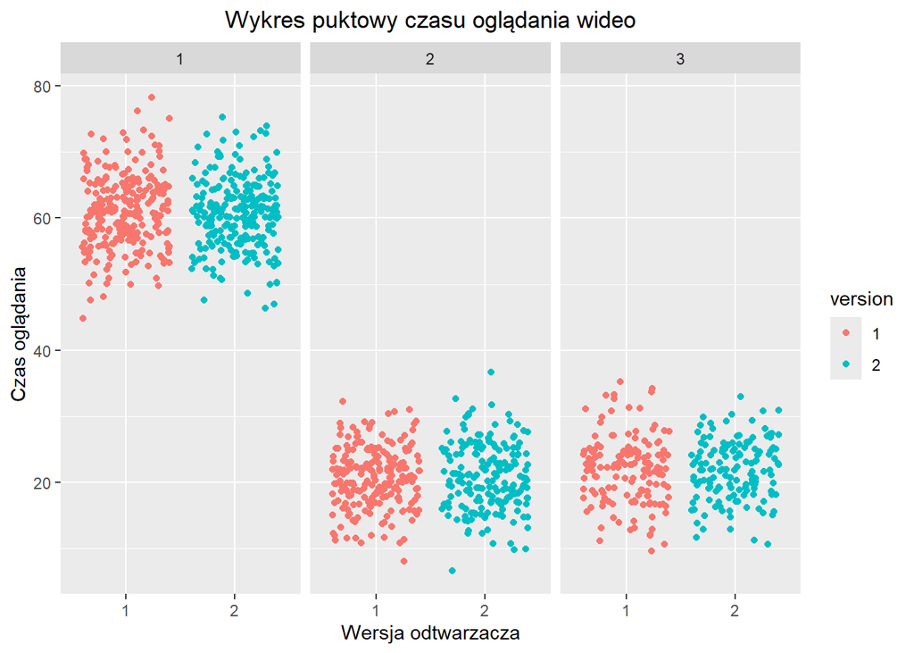

```r
ggplot(data = player, aes(x=version, y = time, color = version)) + geom_jitter() + facet_wrap(~group)+labs(title = "Wykres puktowy czasu oglądania wideo", x='Wersja odtwarzacza', y='Czas oglądania')+ theme(plot.title = element_text(hjust = 0.5))
```

Na podstawie wykresu możemy zauważyć, że obserwacje w każdej grupie są równomiernie rozłożone wokół swoich średnich. W związku z tym przyjmujemy założenie o jednorodności wariancji.

Dodatkowo, korzystając z funkcji *summary*, zweryfikujemy, czy grupy mają podobną liczebność. Należy jednak pamiętać, że nie oczekujemy idealnej równoliczności, a drobne różnice między grupami są akceptowalne.

```r
summary(player)
```

```
##  group        time       version
##  1:500   Min.   : 7.00   1:616
##  2:400   1st Qu.:20.00   2:584
##  3:300   Median :26.00
##          Mean   :37.75
##          3rd Qu.:60.00
##          Max.   :78.00
```

Sprawdźmy teraz, czy pomiędzy rozważanymi czynnikami, czyli grupą użytkowników oraz wersją odtwarzacza, występuje interakcja.

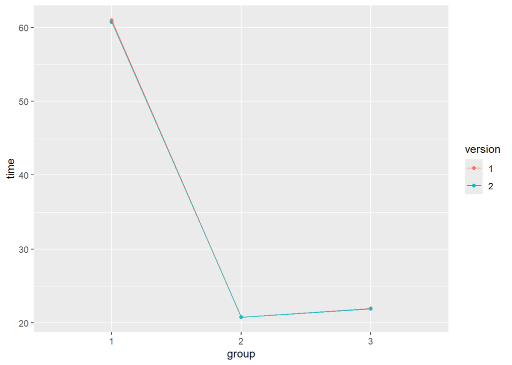

```r
ggplot(player, aes(x=group, y=time, color=version, group=version)) + stat_summary(fun=mean, geom = 'point') + stat_summary(fun=mean, geom='line')
```

Na podstawie przedstawionego wykresu nie możemy mówić o interakcji pomiędzy zmiennymi jakościowymi, ponieważ linie są równoległe względem siebie.

W związku z tym, że założenia dla dwuczynnikowej analizy wariancji zostały spełnione, możemy przystąpić do jej wykonania.

```r
summary(aov(time ~ group*version,data=player))
```

```
##                 Df Sum Sq Mean Sq  F value Pr(>F)
## group            2 456806  228403 9156.987 <2e-16 ***
## version          1      5       5    0.197  0.657
## group:version    2      5       2    0.092  0.912
## Residuals     1194  29782      25
## ---
## Signif. codes:  0 '***' 0.001 '**' 0.01 '*' 0.05 '.' 0.1 ' ' 1
```

Skoro uzyskana wartość **p-value** jest mniejsza niż $0,05$, przyjmujemy hipotezę alternatywną, odrzucając hipotezę zerową. Oznacza to, że czas oglądania wideo różni się pomiędzy grupami użytkowników. Zauważmy, że wartość **p-value** dla zmiennej wersja odtwarzacza oraz interakcji między zmiennymi jakościowymi jest większa niż $0,05$ (wynosząc odpowiednio $0,657$ i $0,912$). W związku z tym w obu przypadkach przyjmujemy hipotezę zerową, co wskazuje, że nie ma istotnej statystycznie różnicy w czasie spędzonym na oglądaniu wideo między nową a starą wersją odtwarzacza.

Na podstawie przeprowadzonej dwuczynnikowej analizy wariancji nie jesteśmy w stanie odpowiedzieć na pytanie inżynierów dotyczące wpływu nowej wersji odtwarzacza na czas oglądania wideo przez dzieci, ponieważ na poziomie populacji nie stwierdzono interakcji między zmiennymi jakościowymi. Możemy jednak wykazać, która grupa użytkowników różni się od pozostałych pod względem czasu spędzonego na oglądaniu wideo.

```r
TukeyHSD(aov(time ~ group, data = player))
```

```
##   Tukey multiple comparisons of means
##     95% family-wise confidence level
##
## Fit: aov(formula = time ~ group, data = player)
##
## $group
##           diff         lwr        upr     p adj
## 2-1 -40.063000 -40.8483245 -39.277676 0.0000000
## 3-1 -38.901333 -39.7562863 -38.046380 0.0000000
## 3-2   1.161667   0.2675354   2.055798 0.0066346
```

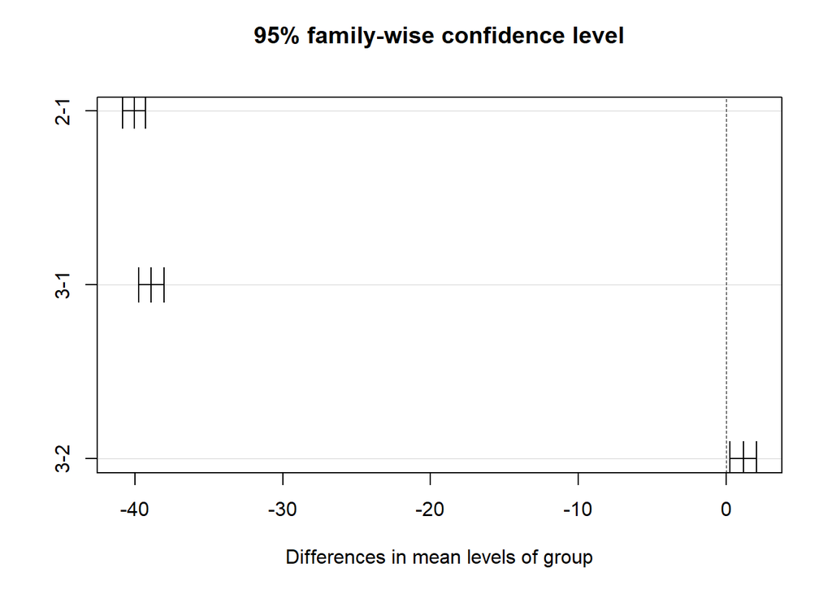

```r
plot(TukeyHSD(aov(time ~ group, data = player)))
```

# Analiza Wpływu Czynników na Ilość Zajętego Miejsca w Chmurze

Zarząd ,,Firmy na A” powierzył zespołowi złożone zadanie analizy danych dotyczących nowej platformy przechowywania danych w chmurze. Platforma oferuje użytkownikom darmowe miejsce z wolnym transferem oraz możliwość dokupienia większej ilości miejsca za opłatą. Dodatkowo, dostępna jest subskrypcja, która zwiększa prędkość transferu.

Na potrzeby tego zadania przymujemy, że jeżeli osoba zajmuje dużo miejsca w swojej chmurze, to chętniej zapłaci za więcej miejsca (poprawność tego założenia samo w sobie jest ciekawym pytaniem, ale na ten moment nie zajmiemy się odpowiedzią na nie).

Zebrane dane obejmują następujące zmienne:

- **sex**: Płeć użytkownika
- **paid**: Informacja, czy użytkownik posiada płatną subskrypcję (0 - nie, 1 - tak)
- **agegrp**: Grupy wiekowe, takie jak w zadaniu 2
- **majoritydata**: Rodzaj danych zajmujących największą część miejsca posiadanego przez użytkownika (1 - wideo, 2 - obrazy, 3 - muzyka, 4 - inne)
- **active**: Czy użytkownik wgrywał jakiekolwiek pliki w ciągu ostatnich dwóch miesięcy (0 - nie, 1 - tak)
- **used**: Ilość zajętego miejsca w chmurze (w GB)

```r
storage <- readr::read_csv('zadanie3.csv')
summary(storage)
```

```
##   majoritydata       used             sex            active
##  Min.   :1.00   Min.   : 100.0   Min.   :0.000   Min.   :0.000
##  1st Qu.:2.00   1st Qu.: 878.8   1st Qu.:0.000   1st Qu.:0.000
##  Median :3.00   Median :1079.5   Median :0.000   Median :0.000
##  Mean   :2.52   Mean   :1205.3   Mean   :0.486   Mean   :0.464
##  3rd Qu.:3.00   3rd Qu.:1393.5   3rd Qu.:1.000   3rd Qu.:1.000
##  Max.   :4.00   Max.   :3349.0   Max.   :1.000   Max.   :1.000
##      agegrp           paid
##  Min.   :1.000   Min.   :0.0000
##  1st Qu.:1.000   1st Qu.:0.0000
##  Median :2.000   Median :0.0000
##  Mean   :2.154   Mean   :0.4624
##  3rd Qu.:3.000   3rd Qu.:1.0000
##  Max.   :3.000   Max.   :1.0000
```

Aby odpowiedzieć na pytanie, do jakiej grupy osób najlepiej skierować reklamy w celu zwiększenia sprzedaży dodatkowego miejsca w chmurze, przeprowadzimy dwuczynnikową analizę wariancji (**ANOVA**). Na początek należy odpowiednio przygotować dane do analizy statystycznej.

```r
storage <- storage  %>% dplyr::mutate(majoritydata = as.factor(majoritydata)) %>% dplyr::mutate(sex = as.factor(sex)) %>% dplyr::mutate(active = as.factor(active)) %>% dplyr::mutate(agegrp = as.factor(agegrp)) %>% dplyr::mutate(paid = as.factor(paid))
head(storage)
```

| majoritydata | used | sex | active | agegrp | paid |
| --- | --- | --- | --- | --- | --- |
| 1 | 1316 | 1 | 0 | 2 | 1 |
| 1 | 2150 | 0 | 1 | 3 | 1 |
| 1 | 2086 | 0 | 0 | 2 | 1 |
| 1 | 2098 | 1 | 0 | 3 | 1 |
| 1 | 1792 | 0 | 1 | 1 | 1 |
| 1 | 1964 | 1 | 0 | 3 | 1 |

Aby odpowiedzieć na postawione pytanie, skoncentrujemy się na odpowiednich zmiennych. Jako zmienną objaśnianą przyjmiemy ilość zajętego miejsca w chmurze, natomiast czynniki, które będziemy analizować, obejmą grupy użytkowników, podobnie jak w poprzednim zadaniu, oraz płeć. Następnie dokonamy analizy założeń dla dwuczynnikowej analizy wariancji.

Początkowo ocenimy, czy rozkład prób w poszczególnych grupach jest zbliżony do rozkładu normalnego. W tym celu stworzymy wykres typu **boxplot**, który pozwoli nam wizualizować rozkłady danych w każdej z analizowanych grup.

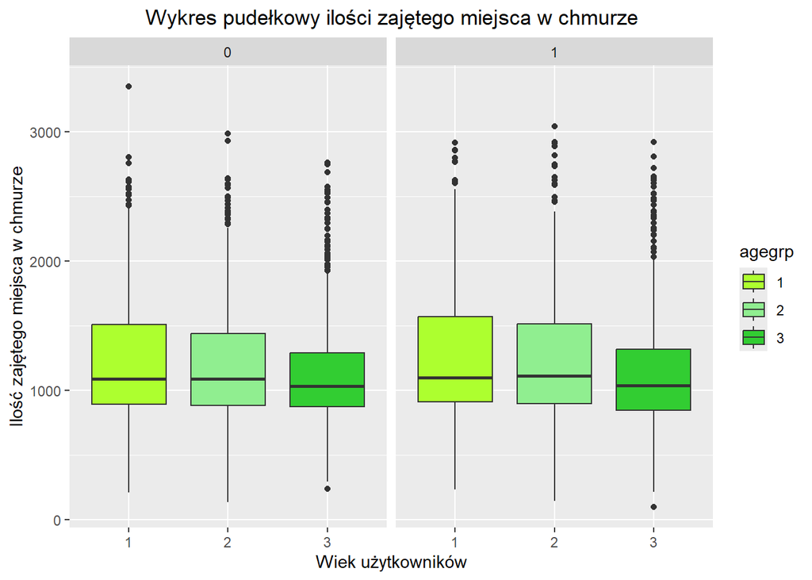

```r
ggplot(storage, aes(x=agegrp, y=used,fill=agegrp)) + geom_boxplot() + facet_wrap(~sex)+labs(title = "Wykres pudełkowy ilości zajętego miejsca w chmurze", x='Wiek użytkowników', y='Ilość zajętego miejsca w chmurze')+scale_fill_manual(values=c("#ADFF2F", "#90EE90", "#32CD32"))+ theme(plot.title = element_text(hjust = 0.5))
```

Zauważmy, że rozkład prób dla każdej grupy jest zbliżony do rozkładu normalnego.

Za pomocą wykresu punktowego ocenimy, czy wszystkie obserwacje w ramach poszczególnych grup mają stałą i równą wariancję.

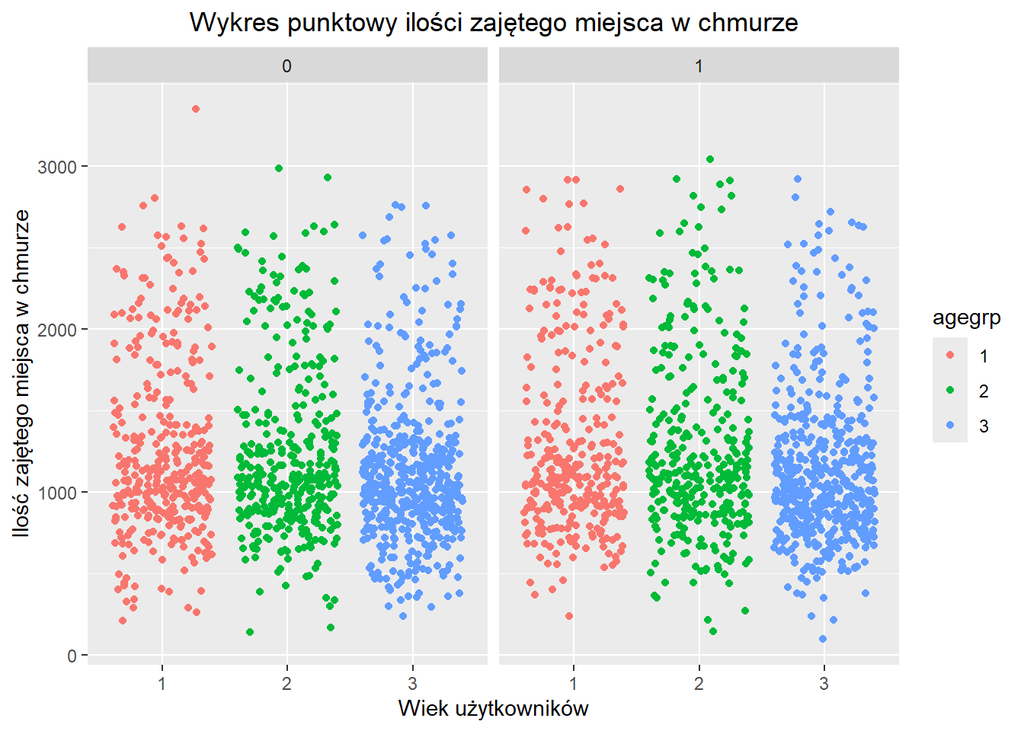

```r
ggplot(data = storage, aes(x=agegrp, y = used, color = agegrp)) + geom_jitter() + facet_wrap(~sex)+labs(title = "Wykres punktowy ilości zajętego miejsca w chmurze", x='Wiek użytkowników', y='Ilość zajętego miejsca w chmurze') + theme(plot.title = element_text(hjust = 0.5))
```

Analizując powyższy wykres, możemy stwierdzić, że obserwacje w każdej grupie są równomiernie rozłożone wokół swoich średnich. W związku z tym przyjmujemy założenie o jednorodności wariancji.

Dodatkowo, wykorzystując funkcję *summary*, dokonamy weryfikacji, czy liczba obserwacji w poszczególnych grupach jest zbliżona.

```r
summary(storage)
```

```
##  majoritydata      used        sex      active   agegrp   paid
##  1:500        Min.   : 100.0   0:1285   0:1340   1: 695   0:1344
##  2:700        1st Qu.: 878.8   1:1215   1:1160   2: 726   1:1156
##  3:800        Median :1079.5                     3:1079
##  4:500        Mean   :1205.3
##               3rd Qu.:1393.5
##               Max.   :3349.0
```

Sprawdźmy teraz, czy między rozważanymi czynnikami, czyli grupą użytkowników a płcią, występuje interakcja.

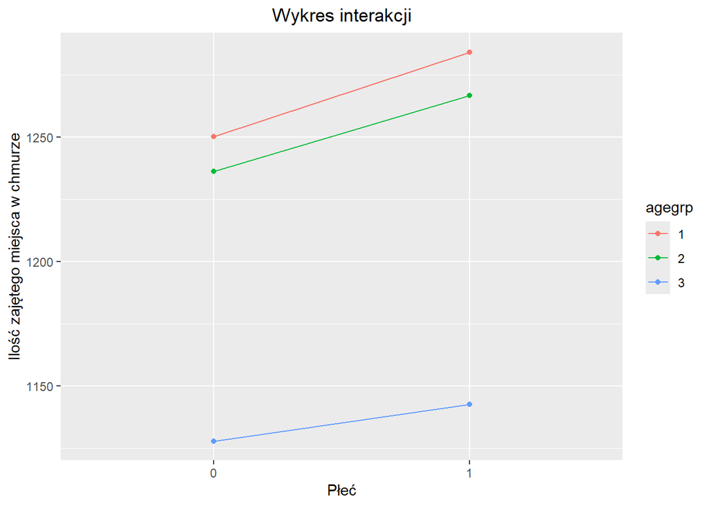

```r
ggplot(storage, aes(x=sex, y=used, color=agegrp, group=agegrp)) + stat_summary(fun=mean, geom = 'point') + stat_summary(fun=mean, geom='line')+labs(title = "Wykres interakcji", x='Płeć', y='Ilość zajętego miejsca w chmurze')+ theme(plot.title = element_text(hjust = 0.5))
```

Na podstawie powyższego wykresu możemy stwierdzić, że nie występuje interakcja między zmiennymi jakościowymi, ponieważ linie są równoległe względem siebie.

Ponieważ wszystkie założenia dla dwuczynnikowej analizy wariancji zostały spełnione, możemy przystąpić do jej przeprowadzenia.

```r
summary(aov(used ~ agegrp*sex, data=storage))
```

```
##               Df    Sum Sq Mean Sq F value   Pr(>F)
## agegrp         2   9425264 4712632  18.342 1.24e-08 ***
## sex            1    377982  377982   1.471    0.225
## agegrp:sex     2     47978   23989   0.093    0.911
## Residuals   2494 640780227  256929
## ---
## Signif. codes:  0 '***' 0.001 '**' 0.01 '*' 0.05 '.' 0.1 ' ' 1
```

W przypadku zmiennej objaśniającej *agegrp* uzyskana wartość **p-value** ($p<0,001$) jest mniejsza od ustalonego poziomu istotności, co daje podstawy do odrzucenia hipotezy zerowej. W związku z tym możemy stwierdzić, że wiek użytkowników ma wpływ na ilość zajętego miejsca w chmurze. Dodatkowo warto zauważyć, że wartość **p-value** dla płci oraz interakcji między zmiennymi jakościowymi (płci a wiekiem użytkowników) wynosi odpowiednio $0,225$ i $0,911$, co jest większe niż $0,05$. W związku z tym w obu przypadkach przyjmujemy hipotezę zerową, co oznacza, że płeć oraz interakcja między tymi zmiennymi nie mają statystycznie istotnego wpływu na ilość zajętego miejsca w chmurze.

Ponieważ wynik analizy wariancji jedynie wskazuje na różnice w ilości zajętego miejsca w chmurze między trzema grupami wiekowymi, przeprowadzimy procedurę Tukeya-Kramera. Pozwoli nam to zidentyfikować, która grupa użytkowników średnio zajmowała więcej miejsca w chmurze w porównaniu do pozostałych grup.

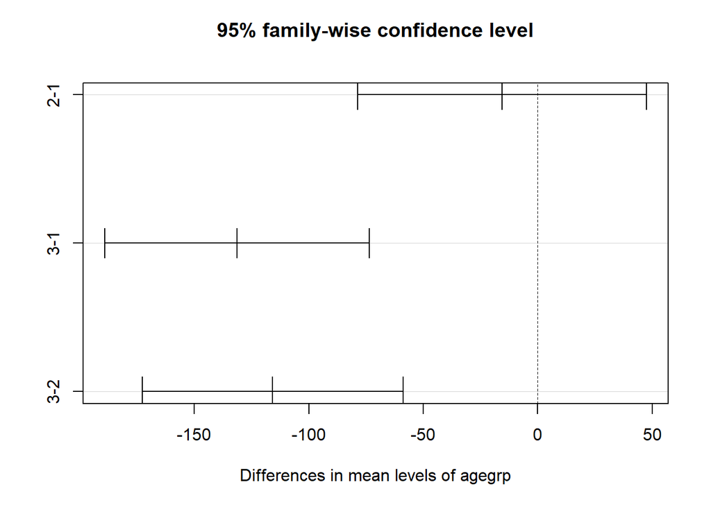

```r
plot(TukeyHSD(aov(used ~ agegrp, data=storage)))
```

# Dodatkowy przykład

Celem niniejszego projektu jest określenie, do której grupy użytkowników najlepiej skierować reklamy, aby skutecznie zwiększyć sprzedaż dodatkowego miejsca w chmurze.

Aby osiągnąć ten cel, przeprowadzimy dwuczynnikową analizę wariancji (**ANOVA**), która pozwoli na zbadanie wpływu wybranych czynników na ilość zajętego miejsca w chmurze. Zmienną objaśnianą w naszym badaniu będzie ilość zajmowanego miejsca przez użytkowników, natomiast zmiennymi objaśniającymi będą: *agegrp*, reprezentująca różne grupy wiekowe, oraz *paid*, wskazująca na posiadanie płatnej subskrypcji.

Przeanalizowanie wpływu tych czynników umożliwi nam identyfikację segmentów rynku, które są bardziej skłonne do zakupu dodatkowego miejsca, a tym samym pozwoli na efektywniejsze targetowanie kampanii reklamowych. Nasze wnioski będą miały na celu dostarczenie praktycznych rekomendacji dla działu marketingu, aby maksymalizować przychody związane z usługami przechowywania danych w chmurze.

Na początek przeanalizujmy założenia dotyczące dwuczynnikowej analizy wariancji. Rozpocznijmy od sprawdzenia, czy rozkład prób w każdej grupie jest zbliżony do rozkładu normalnego.

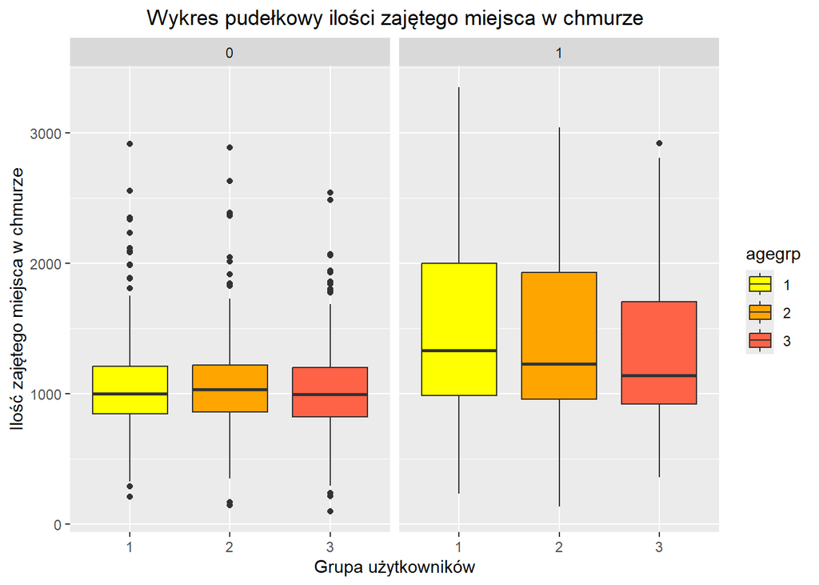

```r
ggplot(storage, aes(x=agegrp, y=used,fill=agegrp)) + geom_boxplot() + facet_wrap(~paid)+labs(title = "Wykres pudełkowy ilości zajętego miejsca w chmurze", x='Grupa użytkowników', y='Ilość zajętego miejsca w chmurze')+scale_fill_manual(values=c("#FFFF00", "#FFA500", "#FF6347"))+ theme(plot.title = element_text(hjust = 0.5))
```

Na podstawie powyższych wykresów możemy stwierdzić, że rozkład prób dla każdej grupy jest zbliżony do rozkładu normalnego. Dodatkowo zauważamy, że w przypadku użytkowników posiadających płatną subskrypcję rozstęp międzykwartylowy, wskazujący na większe rozproszenie danych dotyczących ilości zajmowanego miejsca w chmurze, jest znacznie większy niż w grupie osób bez płatnej subskrypcji.

Przejdźmy teraz do analizy, aby sprawdzić, czy obserwacje w poszczególnych grupach mają stałą i równą wariancję.

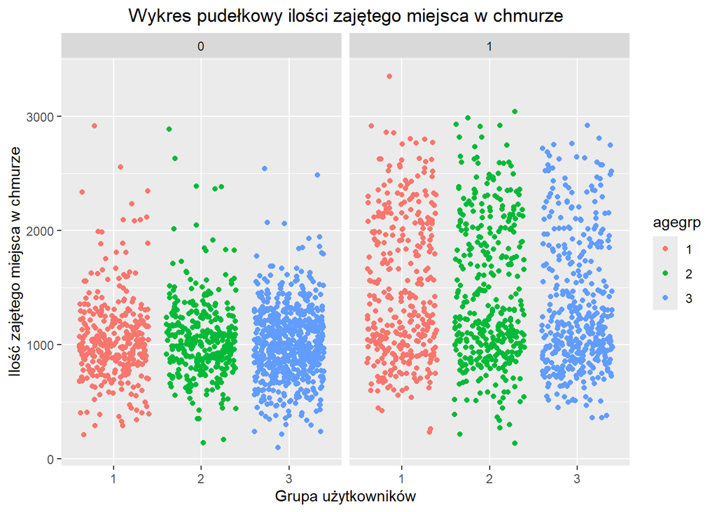

```r
ggplot(data = storage, aes(x=agegrp, y = used, color = agegrp)) + geom_jitter() + facet_wrap(~paid)+ facet_wrap(~paid)+labs(title = "Wykres pudełkowy ilości zajętego miejsca w chmurze", x='Grupa użytkowników', y='Ilość zajętego miejsca w chmurze')+ theme(plot.title = element_text(hjust = 0.5))
```

Przejdźmy teraz do analizy interakcji między czynnikami *agegrp* i *paid*.

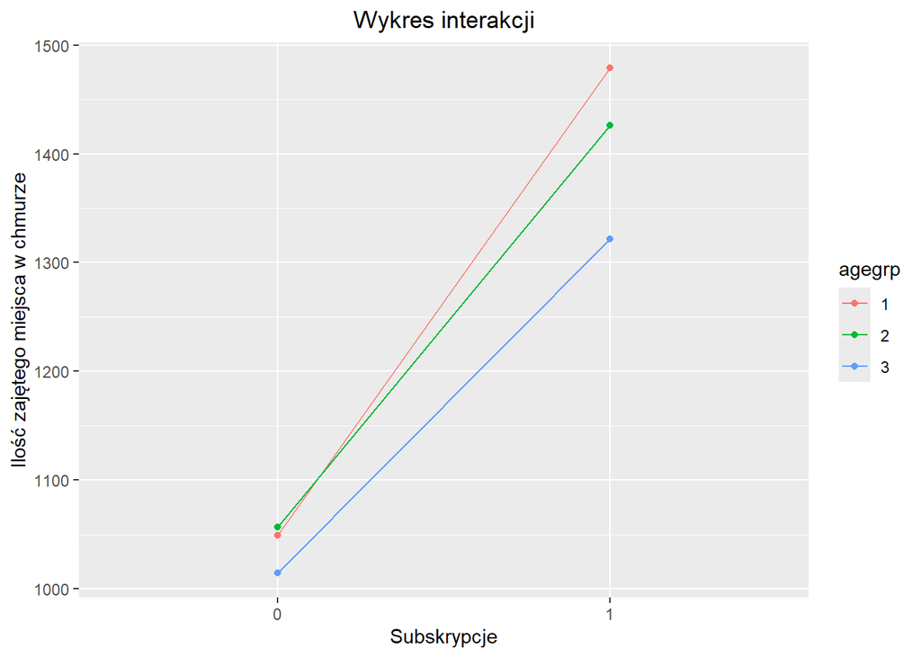

```r
ggplot(storage, aes(x=paid, y=used, color=agegrp, group=agegrp)) + stat_summary(fun=mean, geom = 'point') + stat_summary(fun=mean, geom='line')+labs(title = "Wykres interakcji", x='Subskrypcje', y='Ilość zajętego miejsca w chmurze')+ theme(plot.title = element_text(hjust = 0.5))
```

Na powyższym wykresie możemy zauważyć interakcję między pierwszą a drugą grupą wiekową badanych użytkowników, ponieważ odpowiadające im linie się przecinają.

Przejdźmy teraz do przeprowadzenia dwuczynnikowej analizy wariancji.

```r
summary(aov(used ~ agegrp*paid, data=storage))
```

```
##               Df    Sum Sq  Mean Sq F value   Pr(>F)
## agegrp         2   9425264  4712632  20.982 9.19e-10 ***
## paid           1  79459512 79459512 353.778  < 2e-16 ***
## agegrp:paid    2   1587387   793693   3.534   0.0293 *
## Residuals   2494 560159288   224603
## ---
## Signif. codes:  0 '***' 0.001 '**' 0.01 '*' 0.05 '.' 0.1 ' ' 1
```

Uzyskana wartość **p-value** dla zmiennych jakościowych *agegrp* ($p<0,001$) oraz *paid* ($p<0,001$) wskazuje na istotny statystycznie wpływ wieku użytkowników oraz rodzaju subskrypcji na ilość zajętego miejsca w chmurze. Warto jednak zauważyć, że między tymi zmiennymi zachodzi interakcja, ponieważ wartość **p-value** wynosi $0,0293$, co jest niższe od przyjętego poziomu istotności. W związku z tym odrzucamy hipotezę zerową na rzecz hipotezy alternatywnej.

Aby dokładniej porównać różnice między grupami użytkowników oraz rodzajem subskrypcji a ilością zajmowanego miejsca w chmurze, przeprowadzimy procedurę Tukeya-Kramera.

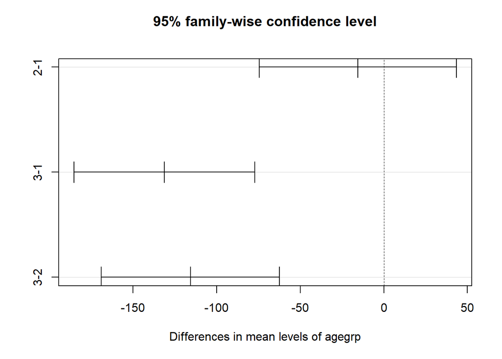

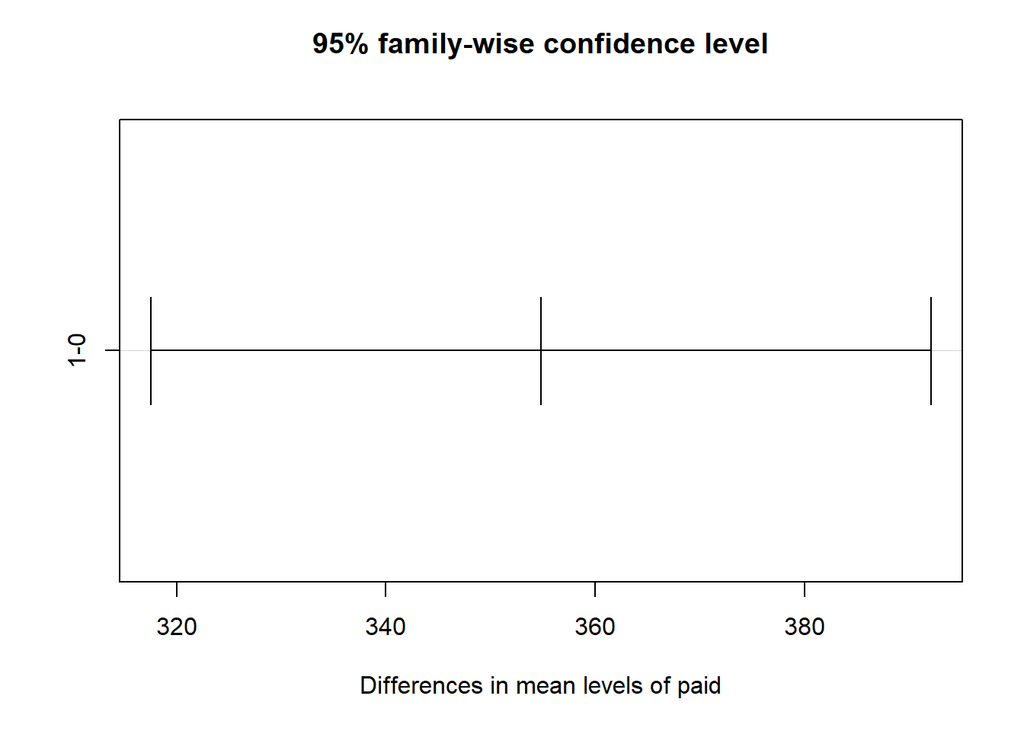

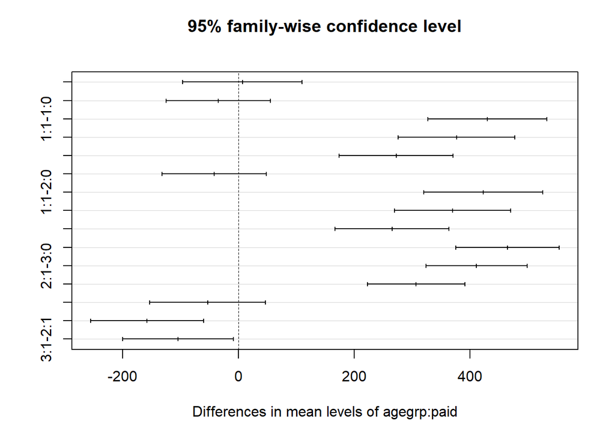

```r
plot(TukeyHSD(aov(used ~ agegrp*paid, data=storage)))
```